# 5. Frekvencijska analiza i sektorski dijagrami

U ovoj lekciji ćeš naučiti:

1. kako da izvršiš *frekvencijsku analizu* niza podataka (što je jedno komplikovano ime za jednu veoma jednostavnu i korisnu stvar); i
2. kako da prikažeš zastupljenost nekih veličina na sektorskom dijagramu.

## 5.1. Frekvencijska analiza niza podataka

*Frekvencijska analiza* niza podataka se svodi na to da se prebroje podaci u nizu i da se na osnovu tako dobijenih *frekvencija podataka* pokuša doći do nekog zaključka (reč *frekvencija* znači "učestalost"). Na primer, u jednom razredu ima 30 učenika i njihove ocene iz informatike su date u sledećem nizu:

```python
oceneInf = [3, 4, 5, 4, 5, 3, 4, 5, 2, 4, 5, 4, 5, 4, 2, 3, 1, 4, 5, 4, 3, 2, 3, 4, 5, 4, 5, 5, 4, 3]
```

Frekvencijska analiza ovog niza se svodi na to da se utvrdi koliko ima petica, četvorki, trojki, dvojki i jedinica u tom razredu. Umesto da to uradimo ručno (recimo, da napravimo tabelicu pa da "lupamo recke"), pustićemo Pajton da to uradi za nas. Pajton ima ugrađenu funkciju `count` koja može da prebroji koliko puta se u nekoj listi javlja neki element:

```python
ocena5 = oceneInf.count(5)
ocena4 = oceneInf.count(4)
ocena3 = oceneInf.count(3)
ocena2 = oceneInf.count(2)
ocena1 = oceneInf.count(1)
print("Ocene u razredu su raspodeljene kako sledi:")
print("Ocenu 5 ima", ocena5, "ucenika")
print("Ocenu 4 ima", ocena4, "ucenika")
print("Ocenu 3 ima", ocena3, "ucenika")
print("Ocenu 2 ima", ocena2, "ucenika")
print("Ocenu 1 ima", ocena1, "ucenika")
```

```
Ocene u razredu su raspodeljene kako sledi:
Ocenu 5 ima 9 ucenika
Ocenu 4 ima 11 ucenika
Ocenu 3 ima 6 ucenika
Ocenu 2 ima 3 ucenika
Ocenu 1 ima 1 ucenika
```

Za svaku ocenu smo odredili koliko se puta pojavila u listi i dobili smo podatke u *apsolutnim iznosima*.

Ako želimo da odredimo *relativne odnose* brojeva ocena, dobijene brojeve ćemo iskazati u procentima:

```python
ukupno = len(oceneInf)
procenat5 = 100.0 * ocena5 / ukupno
procenat4 = 100.0 * ocena4 / ukupno
procenat3 = 100.0 * ocena3 / ukupno
procenat2 = 100.0 * ocena2 / ukupno
procenat1 = 100.0 * ocena1 / ukupno
print("Ocene u razredu su raspodeljene kako sledi:")
print("Ocenu 5 ima ", round(procenat5, 2), "% ucenika", sep="")
print("Ocenu 4 ima ", round(procenat4, 2), "% ucenika", sep="")
print("Ocenu 3 ima ", round(procenat3, 2), "% ucenika", sep="")
print("Ocenu 2 ima ", round(procenat2, 2), "% ucenika", sep="")
print("Ocenu 1 ima ", round(procenat1, 2), "% ucenika", sep="")
```

```
Ocene u razredu su raspodeljene kako sledi:
Ocenu 5 ima 30.0% ucenika
Ocenu 4 ima 36.67% ucenika
Ocenu 3 ima 20.0% ucenika
Ocenu 2 ima 10.0% ucenika
Ocenu 1 ima 3.33% ucenika
```

Dakle, frekvencijska analiza nam daje vrednosti u *konkretnom iznosu* (recimo, u razredu ima 9 petica, 11 četvorki i tako dalje). Ako ove podatke predstavimo procentima dobijamo podatke koji nam govore o zastupljenosti ocena u *relativnim* odnosima.

Tako, u ovom razredu ima 30% petica (9 / 30 = 30%), 36,67% četvorki (11 / 30 = 36,67%), 20% trojki (6 / 30 = 20%), 10% dvojki (3 / 30 = 10%) i 3,33% jedinica (1 / 30 = 3,33%).

## 5.2. Sektorski dijagrami

U situacijama kada se prikazuje koliko procenata koje komponente učestvuje u sastavu neke celine pogodno je podatke prikazati *sektorskim dijagramom* koji predstavlja krug isečen na isečke poput pice. Krug tada predstavlja celinu (100%), dok isečci predstavljaju komponente koje učestvuju u celini iskazane u procentima.

Na primer, ocene iz informatike su u jednom razredu sa 30 učenika raspodeljene ovako:

| Ocena | Zastupljenost ocene |
| --- | --- |
| 5 | 9 |
| 4 | 11 |
| 3 | 6 |
| 2 | 3 |
| 1 | 1 |

Podatke iz ove tabele ćemo ilustrovati sektorskim dijagramom. Prvo ćemo uvesti biblioteku:

```python
import matplotlib.pyplot as plt
```

Onda ćemo podatke zapisati pomoću dva niza ovako:

```python
frekvencije = [9,   11,  6,   3,   1]
ocene       = ["5", "4", "3", "2", "1"]
```

I sada možemo da pređemo na predstavljanje podataka dijagramom. Funkcija koja podatke predstavlja sektorskim dijagramom se zove `pie` zato što se u američkom slengu sektorski dijagrami zovu *pie charts* = "tortasti dijagrami". Prvi argument predstavlja niz vrednosti, dok se drugim zadaju oznake (engl. *label* = oznaka:):

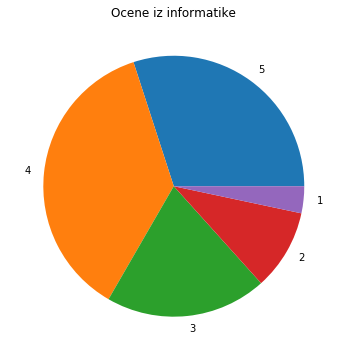

```python
plt.figure(figsize=(6,6))
plt.pie(frekvencije, labels=ocene)
plt.title("Ocene iz informatike")
plt.show()
plt.close()
```

Ako želimo da naglasimo broj petica u razredu možemo odgovarajući sektor da "izmaknemo" malo iz središta. To se postiže argumentom `explode` funkcije `pie` koji za svaki podatak u nizu kaže koliko treba da ga izmaknemo iz središta (0 = ne treba izmestiti sektor iz središta dijagrama; što je veći broj, to je i izmeštanje veće).

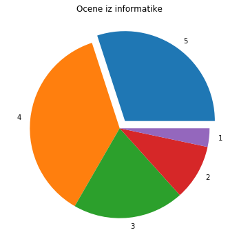

```python
frekvencije = [9,   11,  6,   3,   1]
ocene       = ["5", "4", "3", "2", "1"]
izmestanje  = [0.1, 0,   0,   0,   0]
plt.figure(figsize=(6,6))
plt.pie(frekvencije, labels=ocene, explode=izmestanje)
plt.title("Ocene iz informatike")
plt.show()
plt.close()
```

Kao drugi primer posmatrajmo strukturu naše atmosfere. Naša atmosfera je smeša raznih gasova, a suv vazduh ima sledeći sastav:

| Gas | Zastupljenost (%) |
| --- | --- |
| Azot | 78,08 |
| Kiseonik | 20,94 |
| Argon | 0,93 |
| Ugljen dioksid | 0,05 |

Važno je napomenuti da *ovo nije tačan sastav naše atmosfere:* u njoj ima i drugih gasova, ali u tragovima (kako to hemičari vole da kažu) pa oni nisu prikazani u tabeli.

Strukturu atmosfere ćemo predstaviti sektorskim dijagramom ovako:

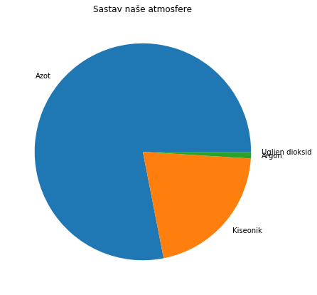

```python
procenti = [78.08,  20.94,      0.93,    0.05]
oznake   = ["Azot", "Kiseonik", "Argon", "Ugljen dioksid"]
plt.figure(figsize=(7,7))
plt.pie(procenti, labels=oznake)
plt.title("Sastav naše atmosfere")
plt.show()
plt.close()
```

Opet nailazimo na problem: oznake za poslednja dva podatka su se preklopile jer se radi o veoma uskom sektorima. Da bismo rešili problem možemo još više da povećamo dijagram, a možemo probati i da poslednja dva "mala" sektora "izmaknemo" iz središta, ovako:

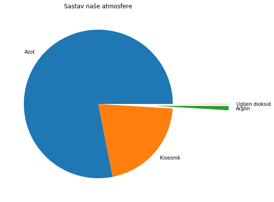

```python
procenti   = [78.08,  20.94,      0.93,    0.05]
oznake     = ["Azot", "Kiseonik", "Argon", "Ugljen dioksid"]
izmestanje = [0,      0,          0.75,    0.75]
plt.figure(figsize=(7,7))
plt.pie(procenti, labels=oznake, explode=izmestanje)
plt.title("Sastav naše atmosfere")
plt.show()
plt.close()
```